# read and plot xpm file

This document demonstrates how to use the **xvm** package and its functions with sample datasets and plots. It also shows how to read multiple xpm files and arrange their plots using ggpubr.

**Note**: Ensure dependency packages are installed:

```r
install.packages(c("ggplot2", "stringr", "ggpubr", "ggnewscale"))
```

### Load the xvm package and dependency packages

Load the xvm package:

```r
# Load the xvm package
library(xvm)
```

Load other dependency packages:

```r
# Load dependency packages
library(ggplot2)
```

## Read a single xpm file and plot it.

### Get Example File Path

Retrieve the path to the example file included in the package:

```r
# This example file is an xpm file containing (free energy landscape, FEL) data generated by GROMACS
gibbs_file_path <- system.file("extdata/gibbs.xpm", package = "xvm")
```

### Read the xpm file

```r
# Read the xpm file using read_xpm() function
gibbs_data <- read_xpm(gibbs_file_path)
```

```
#> Dimensions parsed: width = 32, height = 32, colors = 50
```

```r
# The imported xpm file is stored as a list, with the list name corresponding to the file name.
names(gibbs_data)
```

```
#> [1] "gibbs.xpm"
```

The imported xpm file is stored as a list, so you can simply display the data using the `str()` function.

```r
str(gibbs_data[[1]],max.level = 1)
```

```
#> List of 7
#>  $ data        :'data.frame':    1024 obs. of  5 variables:
#>   ..- attr(*, "out.attrs")=List of 2
#>  $ title       : chr "Gibbs Energy Landscape"
#>  $ legend      : chr "G (kJ/mol)"
#>  $ x_label     : chr "PC1"
#>  $ y_label     : chr "PC2"
#>  $ color_map   :List of 50
#>  $ color_values:List of 50
#>  - attr(*, "class")= chr "xpm_data"
```

The list contains seven elements, each storing different pieces of information:

`$data`: a data frame containing the xpm data.

`$title`: the main title.

`$legend`: the legend labels.

`$x_label`: the label for the x-axis.

`$y_label`: the label for the y-axis.

### Plot the xpm data

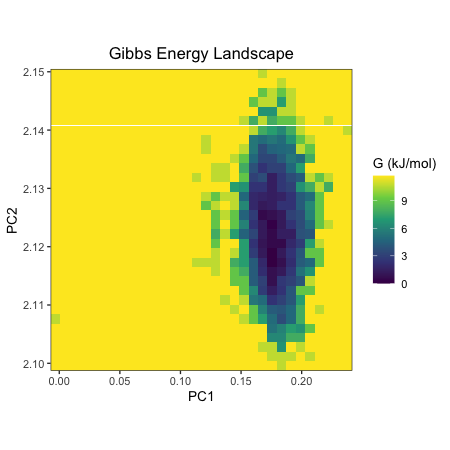

```r
# Plot the xpm data using plot_xpm() function
plot_xpm(gibbs_data)
```

## Read multiple xpm Files

The `read_xpm()` function can accept multiple xpm file paths as a character vector.

```r
# Similarly, you can also read multiple types of xpm files.
multi_file_path <- dir(system.file("extdata", package = "xvm"))

# Filter out xpm files using stringr package
library(stringr)
multi_file_path <- multi_file_path[str_detect(multi_file_path, ".xpm")]
print(multi_file_path)
```

```
#> [1] "entropy.xpm" "gibbs.xpm"
```

```r
# Set the full xvg file paths
multi_file_path <- file.path(system.file("extdata", package = "xvm"),
                             multi_file_path
                             )
```

### Batch read xpm files

```r
# Read multiple xpm files at once in batch:
multi_data <- read_xpm(multi_file_path)
```

```
#> Dimensions parsed: width = 32, height = 32, colors = 50
#>
#> Dimensions parsed: width = 32, height = 32, colors = 50
```

```r
names(multi_data)
```

```
#> [1] "entropy.xpm" "gibbs.xpm"
```

### Inspect a single xpm file

You can view the information of a single xpm file by indexing the list:

```r
# Check the first xpm file info via indexing
str(multi_data[[1]],max.level = 1)
```

```
#> List of 7
#>  $ data        :'data.frame':    1024 obs. of  5 variables:
#>   ..- attr(*, "out.attrs")=List of 2
#>  $ title       : chr "Entropy Landscape"
#>  $ legend      : chr "TDS (kJ/mol)"
#>  $ x_label     : chr "PC1"
#>  $ y_label     : chr "PC2"
#>  $ color_map   :List of 50
#>  $ color_values:List of 50
#>  - attr(*, "class")= chr "xpm_data"
```

### Plot multiple xpm files

Alternatively, use `lapply()` to generate plots for each xpm file:

```r
# Use lapply() to plot all the xpm files in batch
mutli_xpm_plots <- lapply(multi_data, plot_xpm)
```

### Arrange plots using ggpubr

Finally, arrange all plots into a single layout using the `ggarrange()` function from the ggpubr package:

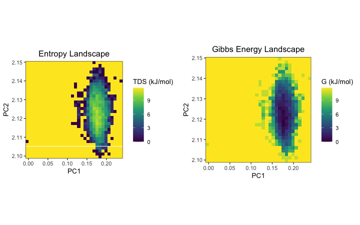

```r
# Arrange the plots using ggpubr
library(ggpubr)
ggarrange(plotlist = mutli_xpm_plots)
```

### Plot pseudo-3D from xpm file

For xpm files representing free energy landscapes, xvm also provides a pseudo-3D plotting function `plot_xpm_facet()`.

The upper plot has PC1 on the x axis, G (kJ/mol) on the y axis, and the color indicates the distance in PC2.

The lower plot has PC2 on the x axis, G (kJ/mol) on the y axis, and the color represents the distance in PC1.

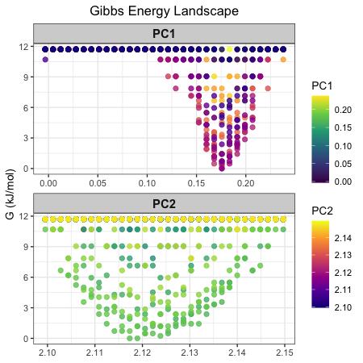

```r
# Usage is similar to the plot_xpm() function
plot_xpm_facet(gibbs_data)
```

### Plot 3D scatter plot from xpm file

xvm also provides a 3D plotting function `plot_xpm_3d()` using `plotly` package.

```r
# Usage is similar to the plot_xpm() function
plot_xpm_3d(gibbs_data)
```

[interactive chart not shown]